# ch05_03_03_model_validation(3)

### 평가 지표 및 측정

#### 1.1.1 최종 목표를 기억하라

#### 1.1.2 이진 분류의 평가지표

### 1.1.3 다중 분류의 평가지표

### 학습 내용

- 다중 분류에서의 오차 행렬을 통해 평가하는 방법에 대해 알아본다.

```python
### 한글
import matplotlib
from matplotlib import font_manager, rc
font_loc = "C:/Windows/Fonts/malgunbd.ttf"
font_name = font_manager.FontProperties(fname=font_loc).get_name()
matplotlib.rc('font', family=font_name)
```

### 01 사전 준비

- 데이터 셋 : 손글씨 데이터 셋

```python
from sklearn.metrics import accuracy_score
from sklearn.datasets import load_digits
from sklearn.model_selection import train_test_split
from sklearn.linear_model import LogisticRegression
from sklearn.metrics import confusion_matrix
```

```python
digits = load_digits()
```

```python
X_train, X_test, y_train, y_test = train_test_split(digits.data,
                                                    digits.target,
                                                    random_state=0)
```

### 02 모델 만들기

- solver : 'newton-cg', 'lbfgs', 'liblinear', 'sag', 'saga' , default=’lbfgs’
  - liblinear : 작은 데이터셋의 경우 좋은 선택
  - 'sag', 'saga' : 큰 데이터셋의 경우 더 빠름.
- multi_class : 'auto', 'ovr', 'multinomial', default = 'auto'
  - 'ovr' : 각 레이블에 이항 문제가 적합, 다항의 경우 전체 확률 분포에 걸쳐 다항 손실이 최소화
  - 'auto' : solver='liblinear' 때는 'ovr' 선택됨. 그렇지않으면 multinomial을 선택
  - 0.22버전에서 기본값이 0.22에서 'ovr'에서 'auto'로 변경

```python
lr = LogisticRegression(solver='liblinear', multi_class='ovr').fit(X_train, y_train)
pred = lr.predict(X_test)

print("정확도 : {:.3f}".format(accuracy_score(y_test, pred)))
print("오차 행렬 :\n", confusion_matrix(y_test, pred))
```

```
정확도 : 0.953
오차 행렬 :
 [[37  0  0  0  0  0  0  0  0  0]
 [ 0 39  0  0  0  0  2  0  2  0]
 [ 0  0 41  3  0  0  0  0  0  0]
 [ 0  0  1 43  0  0  0  0  0  1]
 [ 0  0  0  0 38  0  0  0  0  0]
 [ 0  1  0  0  0 47  0  0  0  0]
 [ 0  0  0  0  0  0 52  0  0  0]
 [ 0  1  0  1  1  0  0 45  0  0]
 [ 0  3  1  0  0  0  0  0 43  1]
 [ 0  0  0  1  0  1  0  0  1 44]]
```

#### 모델의 정확도는 95.3%로 꽤 좋은 성능 좋다.

#### 각 행은 실제 정답 레이블에 해당하며, 열은 예측 레이블에 해당

### 그래프로 표시

```python
import mglearn
import matplotlib.pyplot as plt
```

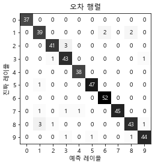

```python
scores_image = mglearn.tools.heatmap(
    confusion_matrix(y_test, pred),
    xlabel='예측 레이블', ylabel='진짜 레이블',
    xticklabels=digits.target_names,
    yticklabels=digits.target_names, cmap=plt.cm.gray_r, fmt="%d")
plt.title("오차 행렬")
plt.gca().invert_yaxis()
```

- 첫번째 클래스는 숫자 0인 샘플이 총 37개, 모두 클래스를 0으로 분류. 클래스 0에는 거짓 음성(FN)이 없음.
- 첫번째 열의 다른 항목들이 모두 0이므로 거짓 양성(FP)가 없음.

### classification_report함수를 사용한 정밀도, 재현율, f1-score점수 확인

```python
from sklearn.metrics import classification_report
```

```python
print(classification_report(y_test, pred))
```

```
              precision    recall  f1-score   support

           0       1.00      1.00      1.00        37
           1       0.89      0.91      0.90        43
           2       0.95      0.93      0.94        44
           3       0.90      0.96      0.92        45
           4       0.97      1.00      0.99        38
           5       0.98      0.98      0.98        48
           6       0.96      1.00      0.98        52
           7       1.00      0.94      0.97        48
           8       0.93      0.90      0.91        48
           9       0.96      0.94      0.95        47

    accuracy                           0.95       450
   macro avg       0.95      0.95      0.95       450
weighted avg       0.95      0.95      0.95       450
```

- 0에는 오차가 없으므로 정밀도와 재현율은 모두 1로 완벽
- 클래스 7은 다른 클래스가 7로 잘못 분류한 것이 없어서 정밀도가 1이다. 45개 중에 45개 맞혔음.
- 클래스 6은 거짓 음성(FN)이 없어서 재현율이 1이다.

#### 다중 분류에서 불균형 데이터셋을 위해 가장 널리 사용하는 평가 지표는 f1-score점수의 다중 분류 버전.

#### 다중 클래스용 f1-score점수는 한 클래스를 양성 클래스로 두고, 나머지 클래스를 음성 클래스로 간주하여 클래스마다 f1-score를 계산

```python
from sklearn.metrics import f1_score
```

```python
print("micro 평균 f1점수 : {:.3f}".format(f1_score(y_test, pred, average='micro')))
print("macro 평균 f1점수 : {:.3f}".format(f1_score(y_test, pred, average='macro')))
```

```
micro 평균 f1점수 : 0.953
macro 평균 f1점수 : 0.954
```